# Tyler Rinker

#### Dissimilarity

*Dissimilarity* is another term for distance that is often used in text analysis to measure the pairwise proximity of grouping variables. The qdap [`Dissimilarity`](http://trinker.github.io/qdap_dev/Dissimilarity.html) function is a wrapper for the R stats package's [dist](http://stat.ethz.ch/R-manual/R-devel/library/stats/html/dist.html) function designed to handle text. [`Dissimilarity`](http://trinker.github.io/qdap_dev/Dissimilarity.html) takes all the same **method** types as [dist](http://stat.ethz.ch/R-manual/R-devel/library/stats/html/dist.html) but also includes the default **method = “prop”** (1 - “binary”) that is focused on the similarity between grouping variables.

♦ **[`Dissimilarity`](http://trinker.github.io/qdap_dev/Dissimilarity.html) Examples**♦

```r
with(DATA, Dissimilarity(state, list(sex, adult)))
```

```
      f.0   f.1   m.0
f.1 0.067
m.0 0.029 0.000
m.1 0.167 0.111 0.000
```

```r
with(DATA, Dissimilarity(state, person))
```

```
            greg researcher sally   sam
researcher 0.000
sally      0.037      0.067
sam        0.160      0.000 0.050
teacher    0.000      0.111 0.167 0.000
```

```r
with(DATA, Dissimilarity(state, person, method = "minkowski"))
```

```
            greg researcher sally   sam
researcher 5.477
sally      5.657      3.742
sam        5.568      4.796 4.796
teacher    5.292      2.828 3.162 4.583
```

```r
dat <- pres_debates2012[pres_debates2012$person %in% qcv(OBAMA, ROMNEY),]
with(dat, Dissimilarity(dialogue, list(person, time)))
```

```
         OBAMA.1 OBAMA.2 OBAMA.3 ROMNEY.1 ROMNEY.2
OBAMA.2    0.340
OBAMA.3    0.300   0.341
ROMNEY.1   0.340   0.287   0.258
ROMNEY.2   0.291   0.349   0.296    0.321
ROMNEY.3   0.264   0.297   0.329    0.290    0.338
```

♦ **[`Dissimilarity`](http://trinker.github.io/qdap_dev/Dissimilarity.html) Clustering (Dendrogram)**♦

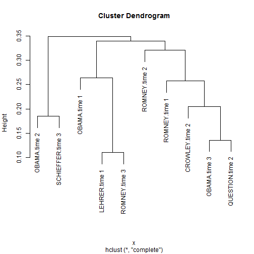

```r
x <- with(pres_debates2012, Dissimilarity(dialogue, list(person, time)))
fit <- hclust(x)
plot(fit)
```

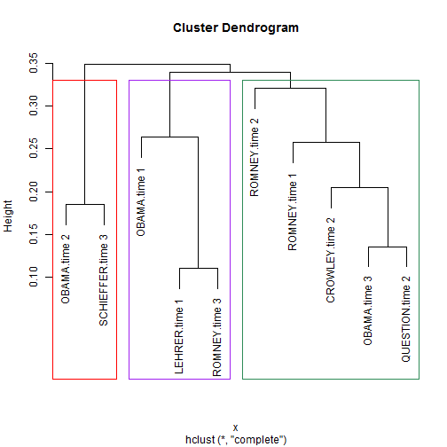

```r
## draw dendogram with colored borders around the 3 clusters
rect.hclust(fit, k=3, border=c("red", "purple", "seagreen"))
```

#### Kullback-Leibler divergence

The Kullback Leibler is often used as a measure of distance, though the matrix is asymmetrical. qdap's [`kullback_leibler`](http://trinker.github.io/qdap_dev/kullback_leibler.html) compares the differences between two probability distributions and often leads to results similar to those from [`Dissimilarity`](http://trinker.github.io/qdap_dev/Dissimilarity.html). Note that unlike many other qdap functions the user must either supply a word frequency matric ([`wfm`](http://trinker.github.io/qdap_dev/Word_Frequency_Matrix.html)) to **x** or some other matrix format. This allows the function to be flexibly used with [`termco`](http://trinker.github.io/qdap_dev/termco.html) and other functions that produce count matrices.

♦ **[`kullback_leibler`](http://trinker.github.io/qdap_dev/kullback_leibler.html) Example** - *Compare to [`Dissimilarity`](http://trinker.github.io/qdap_dev/Dissimilarity.html)*♦

```r
dat <- pres_debates2012[pres_debates2012$person %in% qcv(OBAMA, ROMNEY),]
(KL <- (kullback_leibler(with(dat, wfm(dialogue, list(person, time))))))
```

```
         OBAMA.1 OBAMA.2 OBAMA.3 ROMNEY.1 ROMNEY.2 ROMNEY.3
OBAMA.1    0.000   0.237   0.221    0.195    0.250    0.264
OBAMA.2    0.104   0.000   0.161    0.148    0.142    0.223
OBAMA.3    0.119   0.152   0.000    0.142    0.180    0.168
ROMNEY.1   0.207   0.297   0.279    0.000    0.216    0.224
ROMNEY.2   0.194   0.195   0.262    0.116    0.000    0.234
ROMNEY.3   0.160   0.182   0.141    0.101    0.140    0.000
```

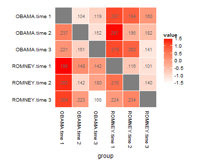

```r
plot(KL, high = "red", values = TRUE)
```

#### Diversity Statistics

Diversity, as applied to dialogue, is a measure of the richness of language being used. Specifically, it measures how expansive the vocabulary is while taking into account the number of total words used and the different words being used. qdap's [`diversity`](http://trinker.github.io/qdap_dev/diversity.html) function provides output for the Simpson, Shannon, Collision, Berger Parker, and Brillouin measures.

♦ **[`diversity`](http://trinker.github.io/qdap_dev/diversity.html) Example**♦

```r
(div.mod <- with(mraja1spl, diversity(dialogue, person)))
```

```
           person   wc simpson shannon collision berger_parker brillouin
1         Abraham   24   0.942   2.405     2.331         0.167     1.873
2        Benvolio  621   0.994   5.432     4.874         0.037     4.809
3         Capulet  736   0.993   5.358     4.805         0.027     4.813
4   First Citizen   16   0.958   2.393     2.287         0.188     1.718
5   First Servant   69   0.983   3.664     3.464         0.072     2.961
6         Gregory  149   0.991   4.405     4.141         0.054     3.686
7          Juliet  206   0.993   4.676     4.398         0.039     3.971
8    Lady Capulet  288   0.993   4.921     4.519         0.042     4.231
9   Lady Montague   28   0.995   3.233     3.199         0.071     2.375
10       Mercutio  549   0.991   5.302     4.564         0.051     4.663
11       Montague  217   0.993   4.805     4.496         0.041     4.063
12          Nurse  599   0.991   5.111     4.561         0.040     4.588
13          Paris   32   0.990   3.276     3.194         0.094     2.449
14         Prince  167   0.990   4.463     4.161         0.048     3.757
15          Romeo 1163   0.994   5.650     4.917         0.026     5.124
16        Sampson  259   0.987   4.531     4.106         0.066     3.947
17 Second Capulet   17   0.963   2.425     2.371         0.118     1.767
18 Second Servant   41   0.993   3.532     3.457         0.073     2.687
19        Servant  184   0.987   4.389     4.023         0.060     3.744
20         Tybalt  160   0.993   4.539     4.345         0.044     3.801
```

♦ **[`diversity`](http://trinker.github.io/qdap_dev/diversity.html) Plot Method**♦

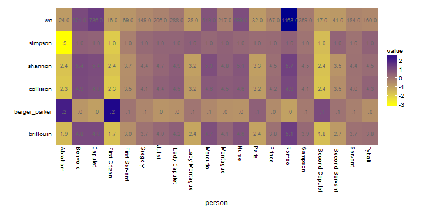

```r
plot(div.mod, low = "yellow", grid = FALSE, values = TRUE)
```

#### Formality

\[ F = 50(\frac{n_{f}-n_{c}}{N} + 1) \]

Where:

\[ f = \left \{noun, \;adjective, \;preposition, \;article\right \} \] \[ c = \left \{pronoun, \;verb, \;adverb, \;interjection\right \} \] \[ N = \sum{(f \;+ \;c \;+ \;conjunctions)} \]

Note that formality utilize parts of speech tagging. This is computationally expensive. The user may gain speed by setting **parallel = TRUE** if multiple cores are available. The user can also “recycle” the output from [`pos`](http://trinker.github.io/qdap_dev/pos.html), [`pos_by`](http://trinker.github.io/qdap_dev/pos.html), or [`formality`](http://trinker.github.io/qdap_dev/formality.html) for the same text. This save considerable time as the parts of speech is saved in the output from these functions as demonstrated in the Recycled Formality Example below.

[`formality`](http://trinker.github.io/qdap_dev/formality.html) also has a plotting method that allows for easy visualization and comparison of formality scores, word counts, formal/contextual parts of speech all by grouping variable(s). Please note that Heylighen & Dewaele (2002) state, “At present, a sample would probably need to contain a few hundred words for the measure to be minimally reliable. For single sentences, the F-value should only be computed for purposes of illustration” (p. 24).

♦ **[`formality`](http://trinker.github.io/qdap_dev/formality.html) Example**♦

```r
form <- with(raj, formality(dialogue, person))
```

♦ **[`formality`](http://trinker.github.io/qdap_dev/formality.html) Plot Method**♦

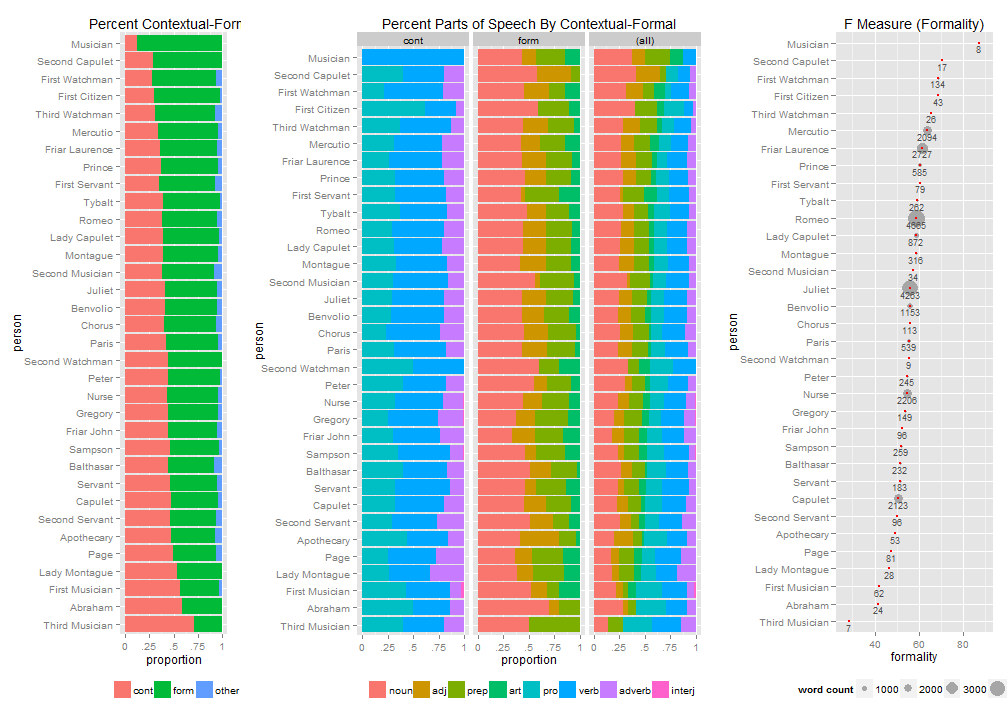

```r
plot(form)
```

♦ **Recycling [`formality`](http://trinker.github.io/qdap_dev/formality.html)**♦

```r
(form2 <- with(raj, formality(form, act)))
```

```
  act word.count formality
1   5       3379     58.38
2   2       5358     58.10
3   1       5525     57.59
4   3       6354     57.22
5   4       3167     55.89
```

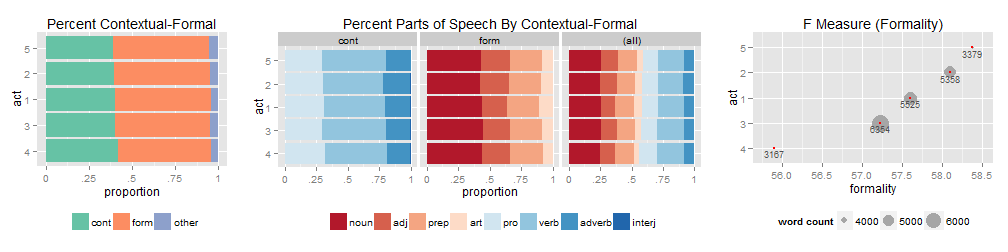

```r
plot(form2, bar.colors=c("Set2", "RdBu"))
```

#### Polarity Score (Sentiment Analysis)

Polarity assignment, a form of sentiment analysis, is using an algorithm to determine the polarity of a sentence/statement. While the use polarity scores is applied to many forms of written social dialogue (e.g., Twitter, Facebook, etc.) it has not typically been applied to spoken dialogue. qdap offers a flexible function, [`polarity`](http://trinker.github.io/qdap_dev/polarity.html) to determine polarity at the sentence level as well as to assign an average polarity score to individual groups within the grouping variable(s). The frame work for [`polarity`](http://trinker.github.io/qdap_dev/polarity.html) is flexible in that the user may supply a polarized dictionary and optional weights. Many dictionaries used in sentiment analysis are designed for written, adult, online interaction.

It is assumed you have run sentSplit on the data.  
If this is not the case the counts will not be accurate.

The polarity score generated by [`polarity`](http://trinker.github.io/qdap_dev/polarity.html) is dependent upon the polarity dictionary used. This function defaults to the word polarity dictionary used by [Hu & Liu (2004)](http://www.cs.uic.edu/~liub/FBS/sentiment-analysis.html), however, this may not be appropriate for the context of children in a classroom. For instance the word “sick” in a high school setting may mean that something is good, whereas “sick” used by a typical adult indicates something is not right or negative connotation. The user may (is encouraged) to provide/augment/alter the dictionary (see the [`sentiment_frame`](http://trinker.github.io/qdap_dev/polarity.html) function). Development of context specific dictionaries, that are better suited for spoken dialogue in a school setting, is an exciting prospect that could lead to greater understanding of the emotional aspects of the spoken word on students. The user may add a dictionary with optional weights as a dataframe within an environment. The [`sentiment_frame`](http://trinker.github.io/qdap_dev/polarity.html) function aides the user in creating the polarity environment.

The equation used by the algorithm to assign value to polarity of each sentence fist utilizes the sentiment dictionary (Hu & Liu, 2004) to tag polarized words. A context cluster of words is pulled from around this polarized word (default 4 words before and two words after) to be considered as valence shifters. The words in this context cluster are tagged as neutral (\(x_i^{0}\)), negator (\(x_i^{N}\)), amplifier (\(x_i^{a}\)), or de-amplifier (\(x_i^{d}\)). Neutral words hold no value in the equation but do affect word count (\(n\)). Each polarized word is then weighted \(w\) based on the weights from the **polarity.frame** argument and then further weighted by the number and position of the valence shifters directly surrounding the positive or negative word. The researcher may provide a weight \(c\) to be utilized with amplifiers/de-amplifiers (default is .8; deamplifier weight is constrained to -1 lower bound). Last, these context cluster (\(x_i^{T}\)) are summed and divided by the square root of the word count (\(\sqrt{n}\)) yielding an unbounded polarity score (\(\delta\)). Note that context clusters containing a comma before the polarized word will only consider words found after the comma.

\[ \delta=\frac{x_i^T}{\sqrt{n}} \]

Where:

\[ x_i^T=\sum{((1 + c(x_i^{A} - x_i^{D}))\cdot w(-1)^{\sum{x_i^{N}}})} \]  
\[ x_i^{A}=\sum{(w_{neg}\cdot x_i^{a})} \]  
\[ x_i^D = \max(x_i^{D'}, -1) \]  
\[ x_i^{D'}=\sum{(- w_{neg}\cdot x_i^{a} + x_i^{d})} \]  
\[ w_{neg}= \left(\sum{x_i^{N}}\right) \bmod {2} \]

The following examples demonstrate how the [`polarity`](http://trinker.github.io/qdap_dev/polarity.html) and [`sentiment_frame`](http://trinker.github.io/qdap_dev/polarity.html) functions operate. Here the polarity for the [`mraja1spl`](http://trinker.github.io/qdap_dev/mraja1spl.html) data set (Act 1 of Romeo and Juliet). The gender, family affiliation and binary died/didn't die are used as the grouping variables.

♦ **[`polarity`](http://trinker.github.io/qdap_dev/polarity.html) Example**♦

```r
 (poldat <- with(mraja1spl, polarity(dialogue, list(sex, fam.aff, died))))
```

```
POLARITY BY GROUP
=================

   sex&fam.aff&died tot.sent tot.word ave.polarity sd.polarity sd.mean.polarity
1       f.cap.FALSE      158     1810        0.076       0.262            0.292
2        f.cap.TRUE       24      221        0.042       0.209            0.204
3       f.mont.TRUE        4       29        0.079       0.398            0.199
4       m.cap.FALSE       73      717        0.026       0.256            0.104
5        m.cap.TRUE       17      185       -0.160       0.313           -0.510
6     m.escal.FALSE        9      195       -0.153       0.313           -0.488
7      m.escal.TRUE       27      646       -0.069       0.256           -0.272
8      m.mont.FALSE       70      952       -0.044       0.384           -0.114
9       m.mont.TRUE      114     1273       -0.004       0.409           -0.009
10     m.none.FALSE        7       78        0.062       0.107            0.583
11  none.none.FALSE        5       18       -0.282       0.439           -0.642
```

```r
names(poldat)
```

```
## [1] "all"    "group"  "digits"
```

♦ **[`polarity`](http://trinker.github.io/qdap_dev/polarity.html)** - *Sentence Level Polarity Scores*♦

```r
htruncdf(poldat$all, 20, 10)
```

```
##    sex&fam.af wc   polarity pos.words  neg.words   text.var
## 1  m.cap.FALS 10          0         -          - Gregory, o
## 2  m.cap.FALS  8          0         -          - No, for th
## 3  m.cap.FALS 11          0         -          - I mean, an
## 4  m.cap.FALS 13          0         -          - Ay, while
## 5  m.cap.FALS  6 -0.4082482         -     strike I strike q
## 6  m.cap.FALS  8 0.35355339         -     strike But thou a
## 7  m.cap.FALS  9          0         -          - A dog of t
## 8  m.cap.FALS 12 0.28867513   valiant          - To move is
## 9  m.cap.FALS 10          0         -          - therefore,
## 10 m.cap.FALS 10          0         -          - A dog of t
## 11 m.cap.FALS 12          0         -          - I will tak
## 12 m.cap.FALS 13 -0.5547001         - c("weak",  That shows
## 13 m.cap.FALS 16      -0.25         -     weaker True; and
## 14 m.cap.FALS 17          0         -          - therefore
## 15 m.cap.FALS 10          0   masters    quarrel The quarre
## 16 m.cap.FALS 10 -0.3162277         -     tyrant 'Tis all o
## 17 m.cap.FALS 21 -0.2182178         -      cruel when I hav
## 18 m.cap.FALS  5          0         -          - The heads
## 19 m.cap.FALS 18 -0.2357022         -       wilt Ay, the he
## 20 m.cap.FALS  9          0         -          - They must
```

♦ **[`polarity`](http://trinker.github.io/qdap_dev/polarity.html) Plot Method**♦

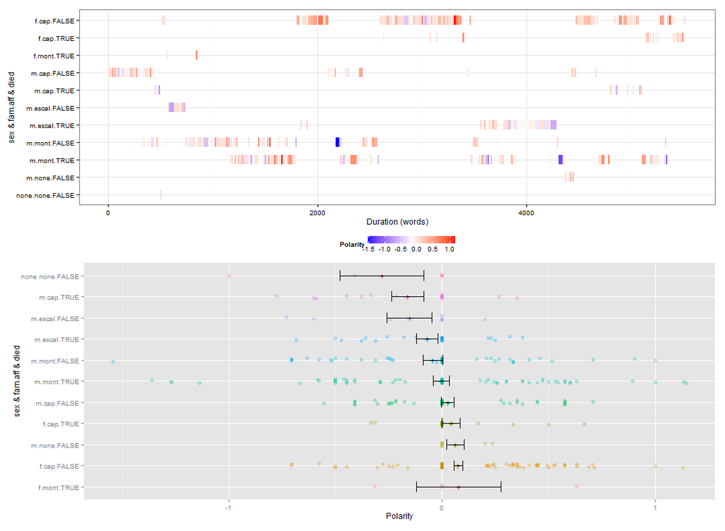

```r
plot(poldat)
```

♦ **[`polarity`](http://trinker.github.io/qdap_dev/polarity.html) Plot Group Polarity as Heat Map**♦

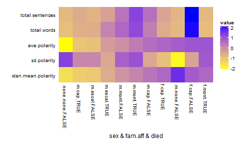

```r
qheat(poldat[["group"]], high="blue", low="yellow", grid=NULL, order.b="ave.polarity")
```

♦ **[`sentiment_frame`](http://trinker.github.io/qdap_dev/sentiment_frame.html)** - *Specify Your Own Polarity Environment*♦

```r
(POLENV <- sentiment_frame(positive.words, negative.words))
```

```
               x  y
   1:     a plus  1
   2:   abnormal -1
   3:    abolish -1
   4: abominable -1
   5: abominably -1
  ---
6775:  zealously -1
6776:     zenith  1
6777:       zest  1
6778:      zippy  1
6779:     zombie -1
```

```r
ls(POLENV)[1:20]
```

```
 [1] "x" "y" NA  NA  NA  NA  NA  NA  NA  NA  NA  NA  NA  NA  NA  NA  NA
[18] NA  NA  NA
```

#### Word Association (Correlations)

It is helpful to finds words associated (or negatively associated) with or correlations between selected words in understanding language selection. The [`wordcor`](http://trinker.github.io/qdap_dev/word_cor.html) function calculates correlations (based on the [`wfm`](http://trinker.github.io/qdap_dev/wfm.html) function) for words nested within grouping variables (turn of talk is an obvious choice for a grouping variable). Running bootstrapping with a random sample can help the researcher determine if a co-occurrence of words is by chance. [`word_cor`](http://trinker.github.io/qdap_dev/word_cor.html) is even more flexible in that it can actually take a frequency matrix (e.g., the [`wfm_combine`](http://trinker.github.io/qdap_dev/wfm.html) function or the cm family of functions).

♦ **[`word_cor`](http://trinker.github.io/qdap_dev/word_cor.html)** - *Single Words*♦

```r
library(reports)
x <- factor(with(rajSPLIT, paste(act, pad(TOT(tot)), sep = "|")))
word_cor(rajSPLIT$dialogue, x, "romeo", .45)
```

```
$romeo
     that    tybalt
0.4540979 0.4831937
```

```r
word_cor(rajSPLIT$dialogue, x, "love", .5)
```

```
$love
 likewise
0.5013104
```

♦ **[`word_cor`](http://trinker.github.io/qdap_dev/word_cor.html)** - *Negative Correlation*♦

```r
word_cor(rajSPLIT$dialogue, x, "you", -.1)
with(rajSPLIT, word_cor(dialogue, list(person, act), "hate"))
```

[output not shown]

```
$hate
 eyesight    knight    prison    smooth     vex'd
0.7318131 0.7318131 0.7318131 0.7318131 0.7318131
```

♦ **[`word_cor`](http://trinker.github.io/qdap_dev/word_cor.html)** - *Multiple Words*♦

```r
words <- c("hate", "i", "love", "ghost")
with(rajSPLIT, word_cor(dialogue, x, words, r = .5))
```

```
$hate
          beasts        beseeming            bills             bred
       0.6251743        0.6251743        0.6251743        0.6251743
        canker'd      capulethold            clubs           coward
       0.6251743        0.6251743        0.6251743        0.6251743
          crutch        disturb'd       flourishes        fountains
       0.6251743        0.6251743        0.6251743        0.6251743
         issuing      mistemper'd neighbourstained        partisans
       0.6251743        0.6251743        0.6251743        0.6251743
      pernicious        profaners           purple       rebellious
       0.6251743        0.6251743        0.6251743        0.6251743
         streets         subjects            sword           thrice
       0.5027573        0.6251743        0.6164718        0.6251743
           throw            wield
       0.6251743        0.6251743

$i
      and      have        me        my      thee        to
0.5150992 0.5573359 0.5329341 0.5134372 0.5101593 0.5533506

$love
 likewise
0.5013104

$ghost
     bone    brains      club      dash     drink      keys kinsman's  methinks
0.7056134 0.7056134 1.0000000 1.0000000 0.5749090 1.0000000 1.0000000 0.5749090
     rage  rapier's   seeking    spices      spit
0.5749090 1.0000000 1.0000000 1.0000000 1.0000000
```

♦ **[`word_cor`](http://trinker.github.io/qdap_dev/word_cor.html)** - *Correlations Between Terms: Example 1*♦

```r
## Set r = NULL to get matrix between words
with(rajSPLIT, word_cor(dialogue, x, words, r = NULL))
```

```
             hate          i        love       ghost
hate   1.00000000 0.05142236  0.15871966 -0.01159382
i      0.05142236 1.00000000  0.36986172  0.01489943
love   0.15871966 0.36986172  1.00000000 -0.02847837
ghost -0.01159382 0.01489943 -0.02847837  1.00000000
```

♦ **[`word_cor`](http://trinker.github.io/qdap_dev/word_cor.html)** - *Correlations Between Terms: Example 2*♦

```r
dat <- pres_debates2012
dat$TOT <- factor(with(dat, paste(time, pad(TOT(tot)), sep = "|")))
dat <- dat[dat$person %in% qcv(OBAMA, ROMNEY), ]
dat$person <- factor(dat$person)
dat.split <- with(dat, split(dat, list(person, time)))

wrds <- qcv(america, debt, dollar, people, tax, health)
lapply(dat.split, function(x) {
    word_cor(x[, "dialogue"], x[, "TOT"], wrds, r=NULL)
})
```

```
$`OBAMA.time 1`
             america       dollar    people          tax      health
america  1.000000000 -0.005979775 0.6117618 -0.005979775  0.13803797
dollar  -0.005979775  1.000000000 0.1650493 -0.004219409 -0.01092353
people   0.611761819  0.165049280 1.0000000  0.165049280  0.50398555
tax     -0.005979775 -0.004219409 0.1650493  1.000000000  0.20572642
health   0.138037974 -0.010923527 0.5039855  0.205726420  1.00000000

$`ROMNEY.time 1`
           america     dollar    people         tax      health
america 1.00000000 0.07493271 0.2336551  0.07033784  0.14986684
dollar  0.07493271 1.00000000 0.5859944  0.11109650  0.33821359
people  0.23365513 0.58599441 1.0000000  0.20584588  0.61333714
tax     0.07033784 0.11109650 0.2058459  1.00000000 -0.01723713
health  0.14986684 0.33821359 0.6133371 -0.01723713  1.00000000

$`OBAMA.time 2`
            america      dollar     people        tax      health
america  1.00000000 -0.01526328 0.41353310 0.07609871  0.25733977
dollar  -0.01526328  1.00000000 0.11671525 0.51222872 -0.01220067
people   0.41353310  0.11671525 1.00000000 0.03761852  0.11285926
tax      0.07609871  0.51222872 0.03761852 1.00000000  0.03431397
health   0.25733977 -0.01220067 0.11285926 0.03431397  1.00000000

$`ROMNEY.time 2`
            america         debt     dollar     people          tax
america  1.00000000 -0.018370290 0.07531545 0.59403781  0.291238391
debt    -0.01837029  1.000000000 0.53340505 0.02329285 -0.009432552
dollar   0.07531545  0.533405053 1.00000000 0.33346752  0.600125943
people   0.59403781  0.023292854 0.33346752 1.00000000  0.516577197
tax      0.29123839 -0.009432552 0.60012594 0.51657720  1.000000000
health   0.06384509 -0.008308652 0.68299026 0.25536510  0.658231340
              health
america  0.063845090
debt    -0.008308652
dollar   0.682990261
people   0.255365102
tax      0.658231340
health   1.000000000

$`OBAMA.time 3`
            america        debt      dollar    people         tax
america  1.00000000 -0.01224452 -0.02326653 0.1182189 -0.02326653
debt    -0.01224452  1.00000000  0.37361771 0.1765301  0.75525297
dollar  -0.02326653  0.37361771  1.00000000 0.1909401  0.70993297
people   0.11821887  0.17653013  0.19094008 1.0000000  0.19094008
tax     -0.02326653  0.75525297  0.70993297 0.1909401  1.00000000

$`ROMNEY.time 3`
          america      debt    dollar    people
america 1.0000000 0.2130341 0.2675978 0.3007027
debt    0.2130341 1.0000000 0.8191341 0.4275521
dollar  0.2675978 0.8191341 1.0000000 0.4666635
people  0.3007027 0.4275521 0.4666635 1.0000000
```

♦ **[`word_cor`](http://trinker.github.io/qdap_dev/word_cor.html)** - *Matrix from [`wfm_combine`](http://trinker.github.io/qdap_dev/wfm.html)*♦

```r
worlis <- list(
    pronouns = c("you", "it", "it's", "we", "i'm", "i"),
    negative = qcv(no, dumb, distrust, not, stinks),
    literacy = qcv(computer, talking, telling)
)
y <- wfdf(DATA$state, id(DATA, prefix = TRUE))
z <- wfm_combine(y, worlis)

word_cor(t(z), word = c(names(worlis), "else.words"), r = NULL)
```

```
             pronouns   negative   literacy else.words
pronouns    1.0000000  0.2488822 -0.4407045 -0.5914760
negative    0.2488822  1.0000000 -0.2105380 -0.7146856
literacy   -0.4407045 -0.2105380  1.0000000  0.2318694
else.words -0.5914760 -0.7146856  0.2318694  1.0000000
```

### Visualizing Discourse Data

The following functions will be utilized in this section (click to view more):

- Lexical Dispersion Plot

- Word Cloud

- Gantt Plot

- Quick Heatmap

- Rank Frequency Plot

- Visualize Word Length by Turn of Talk

- Venn Diagram

- Word Network Plot

qdap offers a number of plot methods for various outputs from functions (use **plot(qdap_FUNCTION_OUTPUT)**). In addition to the numerous plot methods qdap also has several functions dedicated solely to plotting purposes. Many of these functions rely on the [ggplot2 package](http://docs.ggplot2.org/current/) (Wickham, 2009) to produce plots.

#### Lexical Dispersion Plot

The *lexical dispersion plot* is a useful tool (particularly in the early stage of analysis) for looking at the dispersion of a word throughout the dialogue. [`dispersion_plot`](http://trinker.github.io/qdap_dev/dispersion_plot.html) provides the means to look at and compare multiple word dispersions across repeated measures and/or grouping variables. This can be useful in conjunction with a correlation analysis.

The search mechanism used by [`dispersion_plot`](http://trinker.github.io/qdap_dev/dispersion_plot.html) is identical to [`termco`](http://trinker.github.io/qdap_dev/termco.html) and [`term_match`](http://trinker.github.io/qdap_dev/termco.html). For example, **“ love ”** will not yield the same search as **“love”**. The search example below demonstrates the way the search functions. For more information see the termco search description above.

♦ **[`dispersion_plot`](http://trinker.github.io/qdap_dev/dispersion_plot.html)** - *Understand the Search*♦

```r
term_match(raj$dialogue, c(" love ", "love", " night ", "night"))
```

```
$` love `
[1] "love"

$love
 [1] "love"           "love's"         "lovers"         "loved"          "lovely"
 [6] "lovest"         "lover"          "beloved"        "loves"          "newbeloved"
[11] "glove"          "lovesong"       "lovedevouring"  "loveperforming" "dearloved"

$` night `
[1] "night"

$night
[1] "night"       "fortnight"   "nights"      "tonight"     "night's"     "knight"
[7] "nightingale" "nightly"     "yesternight"
```

♦ **[`dispersion_plot`](http://trinker.github.io/qdap_dev/dispersion_plot.html)** - *Example 1*♦

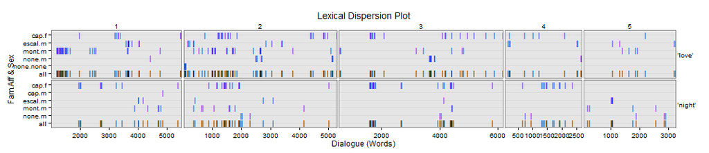

```r
with(rajSPLIT , dispersion_plot(dialogue, c("love", "night"),
    grouping.var = list(fam.aff, sex), rm.vars = act))
```

♦ **[`dispersion_plot`](http://trinker.github.io/qdap_dev/dispersion_plot.html)** - *Example 2: Color Schemes*♦

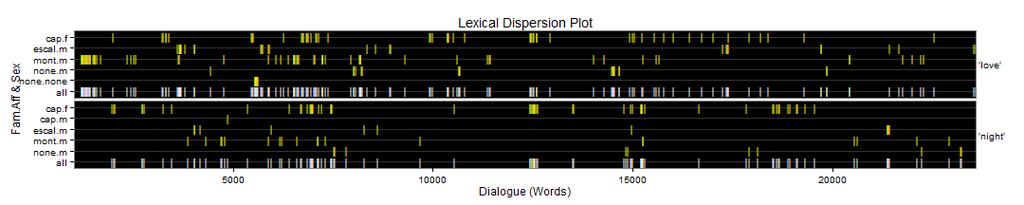

```r
with(rajSPLIT, dispersion_plot(dialogue, c("love", "night"),
    bg.color = "black", grouping.var = list(fam.aff, sex),
    color = "yellow", total.color = "white", horiz.color="grey20"))
```

Using [`dispersion_plot`](http://trinker.github.io/qdap_dev/dispersion_plot.html) with [`freq_terms`](http://trinker.github.io/qdap_dev/freq_terms.html)'s **[[“rfswl”]][[“all”]]** can be a useful means of viewing the dispersion of high frequency words after stopword removal.

♦ **[`dispersion_plot`](http://trinker.github.io/qdap_dev/dispersion_plot.html)** - *Example 3: Using with [`freq_terms`](http://trinker.github.io/qdap_dev/freq_terms.html)*♦

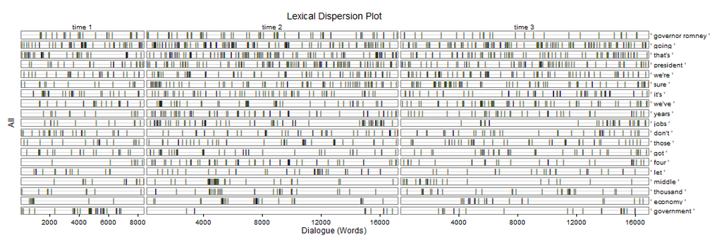

```r
wrds <- freq_terms(pres_debates2012$dialogue, stopwords = Top200Words)

## Add leading/trailing spaces if desired
wrds2 <- spaste(wrds)

## Use `~~` to maintain spaces
wrds2 <- c(" governor~~romney ", wrds2[-c(3, 12)])

## Plot
with(pres_debates2012 , dispersion_plot(dialogue, wrds2, rm.vars = time,
    color="black", bg.color="white"))
```

#### Word Clouds

Wordclouds can be a useful tool to help find words/phrases that are used frequently. It allows for the entire dialogue to be contained in pictorial form. The word cloud becomes more useful in discovering themes when color can be used in a meaningful way (i.e., the information contained in the word size and word color are not redundant). qdap has two word cloud functions (both are wrappers for [wordcloud](http://cran.r-project.org/web/packages/wordcloud/index.html) from the wordcloud package). The [`trans_cloud`](http://trinker.github.io/qdap_dev/trans_cloud.html) function produces word clouds with optional theme coloring by grouping variable. The [`gradient_cloud`](http://trinker.github.io/qdap_dev/gradient_cloud.html) function produces a gradient word cloud colored by a binary grouping variable.

[`trans_cloud`](http://trinker.github.io/qdap_dev/trans_cloud.html) is passed a list of named vectors to **target.words** in much the same way as **match.list** in [`termco`](http://trinker.github.io/qdap_dev/termco.html).

*Format for Named Vectors*

```
list(
    theme_1 = c("word1", "word2", "word3"),
    theme_2 = c("word4", "word5"),
    theme_3 = c("word6", "word7", "word8")
)
```

The **cloud.colors** argument takes a single color or a vector of colors 1 greater than the number of vectors of **target.words**. The order of **cloud.colors** corresponds to the order of **target.words** with the extra, final color being utilized for all words not matched to **target.words**.

♦ **[`trans_cloud`](http://trinker.github.io/qdap_dev/trans_cloud.html) Example 1**♦

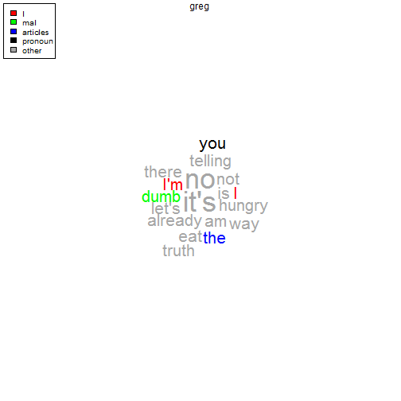

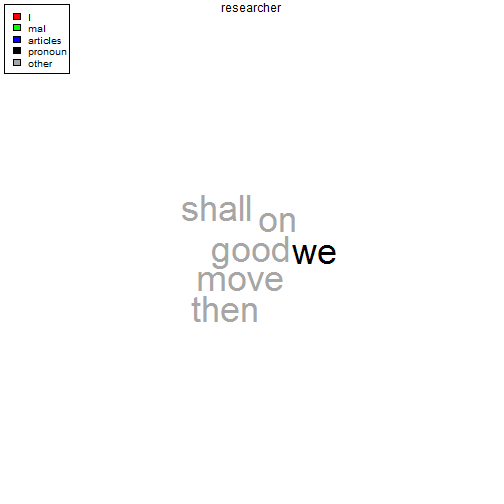

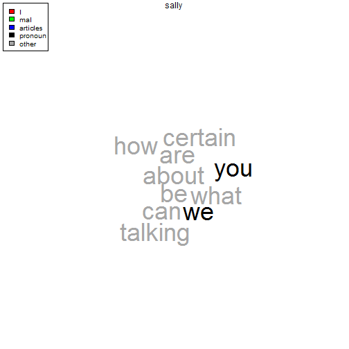

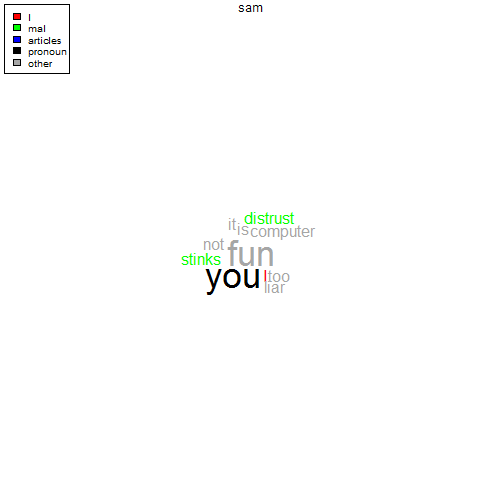

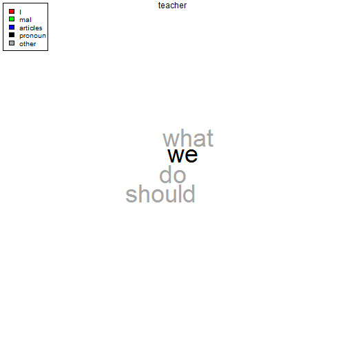

```r
## Generate themes/terms to color by
terms <- list(
    I=c("i", "i'm"),
    mal=qcv(stinks, dumb, distrust),
    articles=qcv(the, a, an),
    pronoun=qcv(we, you)
)

with(DATA, trans_cloud(state, person, target.words=terms,
    cloud.colors=qcv(red, green, blue, black, gray65),
    expand.target=FALSE, proportional=TRUE, legend=c(names(terms),
    "other")))
```

♦ **[`trans_cloud`](http://trinker.github.io/qdap_dev/trans_cloud.html) Example 2** - *Polarity*♦

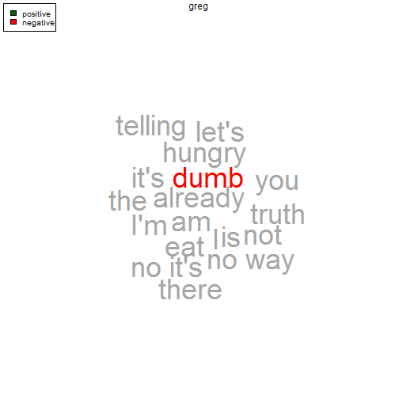

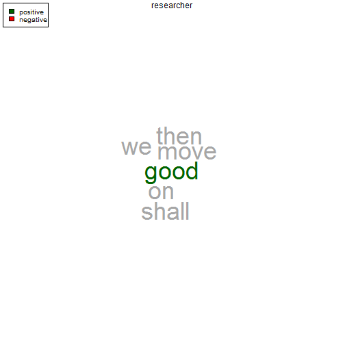

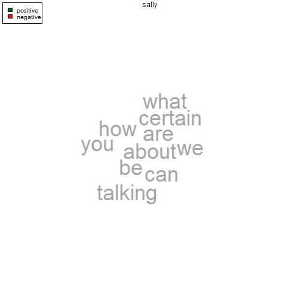

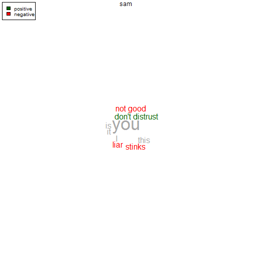

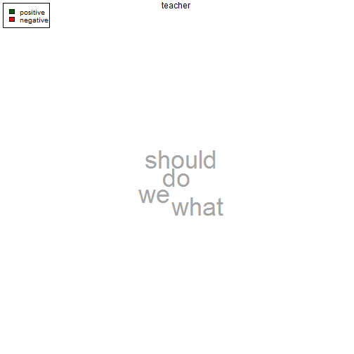

```r
## Rearrange the data
DATA2 <- qdap::DATA
DATA2[1, 4] <- "This is not good!"
DATA2[8, 4] <- "I don't distrust you."
DATA2$state <- space_fill(DATA2$state, paste0(negation.words, " "),
    rm.extra = FALSE)
txt <- gsub("~~", " ", breaker(DATA2$state))
rev.neg <- sapply(negation.words, paste, negative.words)
rev.pos <- sapply(negation.words, paste, positive.words)

## Generate themes/terms to color by
tw <- list(
    positive=c(positive.words, rev.neg[rev.neg %in% txt]),
    negative=c(negative.words, rev.pos[rev.pos %in% txt])
)

with(DATA2, trans_cloud(state, person,
    target.words=tw,
    cloud.colors=qcv(darkgreen, red, gray65),
    expand.target=FALSE, proportional=TRUE, legend=names(tw)))
```

♦ **[`gradient_cloud`](http://trinker.github.io/qdap_dev/gradient_cloud.html) Examples**♦

```r
## Fuse two words
DATA2 <- DATA
DATA2$state <- space_fill(DATA$state, c("is fun", "too fun", "you liar"))
```

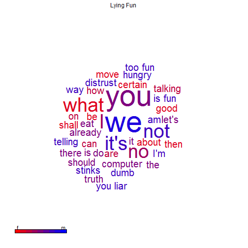

```r
gradient_cloud(DATA2$state, DATA2$sex, title="Lying Fun", max.word.size = 5,
    min.word.size = .025)
```

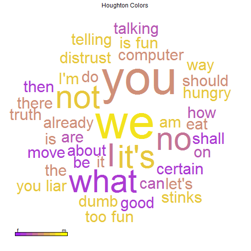

```r
gradient_cloud(DATA2$state, DATA2$sex, title="Houghton Colors",
    max.word.size = 8, min.word.size = .01, X ="purple" , Y = "yellow")
```

#### Gantt Plot

Many of the plot methods utilized by other functions' classes are a wrapper for [`gantt_plot`](http://trinker.github.io/qdap_dev/gantt_plot.html) or [`gantt_wrap`](http://trinker.github.io/qdap_dev/gantt_wrap.html). [`gantt_plot`](http://trinker.github.io/qdap_dev/gantt_plot.html) wraps the [`gantt`](http://trinker.github.io/qdap_dev/gantt.html), [`gantt_rep`](http://trinker.github.io/qdap_dev/gantt_rep.html) and [`gantt_wrap`](http://trinker.github.io/qdap_dev/gantt_wrap.html) functions to allow for direct input of text dialogue and grouping variables. The [`gantt_plot`](http://trinker.github.io/qdap_dev/gantt_plot.html) function is a fast way to make Gantt charts that can be faceted and filled by grouping variables. A Gantt plot allows the user to find trends and patterns in dialogue across time. It essentially allows for a visual representation of an entire exchange of dialogue. The following examples show the flexibility of [`gantt_plot`](http://trinker.github.io/qdap_dev/gantt_plot.html); many of these techniques can also be utilized in plot methods for qdap classes that utilize [`gantt_plot`](http://trinker.github.io/qdap_dev/gantt_plot.html) and [`gantt_wrap`](http://trinker.github.io/qdap_dev/gantt_wrap.html). It is also prudent to be aware of [`gantt_wrap`](http://trinker.github.io/qdap_dev/gantt_wrap.html), that is its arguments and how to utilize it, as it is less convenient yet more flexible and powerful than [`gantt_plot`](http://trinker.github.io/qdap_dev/gantt_plot.html).

♦ **[`gantt_plot`](http://trinker.github.io/qdap_dev/gantt_plot.html)** - *Single Time/Single Grouping Variable*♦

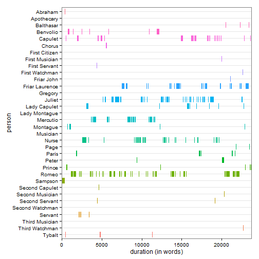

```r
with(rajSPLIT, gantt_plot(text.var = dialogue,
    grouping.var = person, size=4))
```

♦ **[`gantt_plot`](http://trinker.github.io/qdap_dev/gantt_plot.html)** - *Single Time/Multiple Grouping Variable*♦

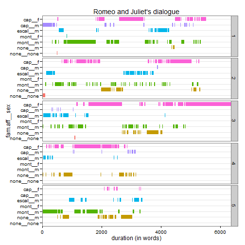

```r
with(rajSPLIT, gantt_plot(text.var = dialogue,
    grouping.var = list(fam.aff, sex), rm.var  = act,
    title = "Romeo and Juliet's dialogue"))
```

Sometimes the location of the facets may not be ideal to show the data (i.e., you may want to reverse the x and y axis). By setting **transform = TRUE** the user can make this switch.

♦ **[`gantt_plot`](http://trinker.github.io/qdap_dev/gantt_plot.html)** - *Transforming*♦

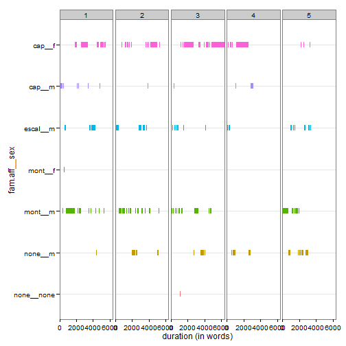

```r
with(rajSPLIT, gantt_plot(dialogue, list(fam.aff, sex), act,
    transform=T))
```

Often the default colors are less useful in displaying the trends in a way that is most meaningful. Because [`gantt_plot`](http://trinker.github.io/qdap_dev/gantt_plot.html) is a wrapper for ggplot2 the color palettes can easily be extended to use with the output from [`gantt_plot`](http://trinker.github.io/qdap_dev/gantt_plot.html).

♦ **[`gantt_plot`](http://trinker.github.io/qdap_dev/gantt_plot.html)** - *Color Palette Examples*♦

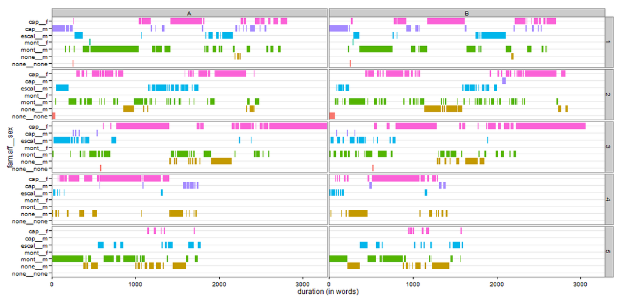

```r
## Load needed packages
library(ggplot2); library(scales); library(RColorBrewer); library(grid)

## Duplicate a new data set and make alterations
rajSPLIT2 <- rajSPLIT

rajSPLIT2$newb <- as.factor(sample(LETTERS[1:2], nrow(rajSPLIT2),
    replace=TRUE))

z <- with(rajSPLIT2, gantt_plot(dialogue, list(fam.aff, sex),
    list(act, newb), size = 4))
```

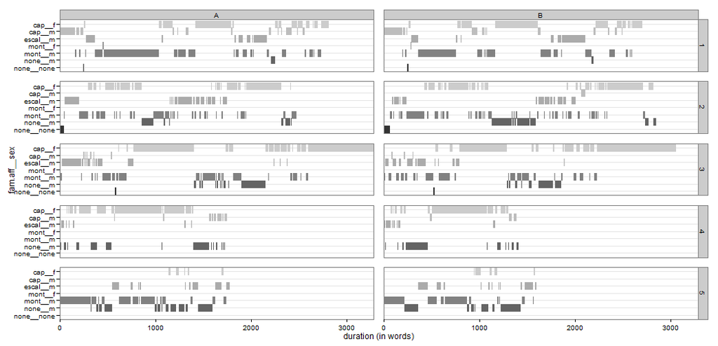

```r
z + theme(panel.margin = unit(1, "lines")) + scale_colour_grey()
```

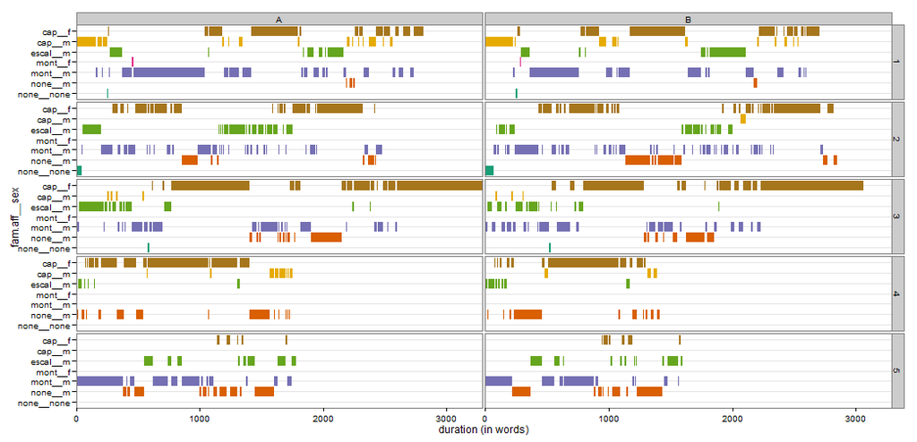

```r
z + scale_colour_brewer(palette="Dark2")
```